# Day 2: Data Import/Export

Ajjit Narayanan

September 12, 2019 14:52

[figure not shown]

# 1 Review

- Making maps in R is really powerful and easy
- The `sf` package handles point and polygon spatial data
- sf objects are dataframes with an additional geometry column

```r
library(urbnmapr)
library(urbnthemes)
library(tidyverse)
library(sf)
library(tigris)
set_urbn_defaults(style = "map")
```

# 2 Reading in spatial data

Out in the wild, spatial data comes in many formats but some of the common ones you will encounter are:

- CSV’s with lon/lat columns
- GeoJSON’s (.geojson)
- Shapefiles (.shp)

the `sf` package has a function called `st_read()` that makes reading in any of these types of files easy.

For GeoJSONs and Shapefiles:

```r
data <- st_read("path/to/geojson/file.geojson")
data <- st_read("path/to/shp/file.shp")
```

For CSV’s:

```r
# You have two options!
# 1- Read in the file using st_read, but maniupulate some GDAL options
data <- st_read("path/to/csv/file.csv",
  options = c("X_POSSIBLE_NAMES=lon", "Y_POSSIBLE_NAMES=lat")
)

# 2- Read in the file as a data frame and convert it to an sf object
data <- read_csv("path/to/csv/file.csv")
data <- st_as_sf(data, coords = c("lon", "lat"))
```

**NOTE: X = Longitude & Y = Latitude.** You will at some point mix these two up, but try to keep them straight.

`st_read` can also accept URL’s!

```r
data <- st_read("https://opendata.arcgis.com/datasets/287eaa2ecbff4d699762bbc6795ffdca_9.geojson")
```

## 2.1 Exercise 1: Create a Project

**Step 1:** Create a new directory called `mapping101`

**Step 2:** Open RStudio. Click “Project: (None)” in the top right corner. Click “New Project” and create a project based on the existing ’mapping101` directory.

**Step 3:** Open a `.R` script with the button in the top left. Save the script as `01_data-import-export.R`.

**Step 4:** `library()` the following packages into your R session: `sf`, `tidyverse`, `urbnthemes`, `urbnmapr`

## 2.2 Exercise 2: Read in a GeoJSON

**Step 1:** Read in data on the locations of all fire stations in DC. Create a variable named `fire_stations` and using `st_read`, read in the following GeoJSON from this URL: https://maps2.dcgis.dc.gov/dcgis/rest/services/DCGIS_DATA/Public_Safety_WebMercator/MapServer/6/query?where=1%3D1&outFields=NAME,ADDRESS,TRUCK,AMBULANCE&outSR=4326&f=geojson

## 2.3 Exercise 3: Read in a CSV

**Step 1:** Copy and paste the following link into your browser to download the CSV to you computer. It’s a dataset on all crimes in DC within the last 30 days. https://geocoding-codestar-test.s3.us-east-2.amazonaws.com/crime_last_30_days.csv

**Step 1:** Create a folder called `data` in your mapping101 folder, and move the downloaded CSV into that folder

**Step 2:** Find the filepath to the CSV (it should be something like ‘data/example.csv’) and read it into R as an sf dataframe named `crime_30`. Note: You may need to open the CSV to see what the X and Y columns are labelled as. You can use any of the two methods described above

# 3 Writing out spatial data

sf has a function called `st_write` that can write out sf objects as GeoJSON’s, shapefiles, CSVS, Geopackages, or just about any other spatial format supported by [GDAL](https://gdal.org/drivers/vector/index.html). We recommend saving your spatial files as GeoJSON’s whenever you can for for a few reasons:

1. It’s a pretty universal file format that can easily be read back into R or other programs like ArcGIS, or Python
2. It uses standardized projections and naming conventions, which saves you a lot of headaches down the road

Writing out GeoJSONs and Shapefiles:

```r
st_write(sf_data, "output/path/filename.geojson")
st_write(sf_data, "output/path/filename.shp")
```

Writing out CSV’s

There may be some cases when you need to write out your spatial data as a CSV to share with other folks. sf does let you do that, but the lat/lon columns will eithter be labelled X/Y or you can get a single WKT column.

| X | Y |
| --- | --- |
| -76.9651 | 38.89204 |

| WKT |
| --- |
| POINT (-76.9651, 38.89204) |

Here’s how you write out CSV’s both ways using `sf_write`:

```r
# Writing out X and Y columsn to CSV
st_write(sf_data, "C:/Users/anarayanan/Downloads/exparkslocations.csv",
  layer_options = "GEOMETRY=AS_XY"
)

# Writing out WKT columns to CSV
st_write(sf_data, "C:/Users/anarayanan/Downloads/exparkslocations.csv",
  layer_options = "GEOMETRY=AS_WKT"
)
```

But sometimes, we want to write out CSVs with human readable Latitude and Longitude columns instead of X and Y columns as they are easy to mix up (quick - is X latitiude or longitude?).SF doesn’t give you the ability to do this easily. So we need to extract the coordinates from the SF dataframe, append them as columns to our dataframe, then rename them latitide/longitude.

```r
# getting lon/lat columns from dataframe
coords = st_coordinates(data) %>%
  as_tibble() %>%
  dplyr::rename(lon = X, lat = Y)

# appending lon/lat columns to dataframe
data = data %>%
  st_set_geometry(NULL) %>%
  bind_cols(coords)

# writing out dataframe as csv
write_csv(data, "path/to/file.csv")
```

## 3.1 Exercise 4: Writing out Spatial data

**Step 1:** Let’s say we were only interested in relatively large fire stations. Use the `filter()` function to limit the `fire_stations` dataframe to stations that have more than 5 trucks (ie `TRUCKS > 5`). Call this filtered dataframe `big_stations`

**Step 2:** Write out the `big_stations` dataframe as a GeoJSON into the `data\` folder we created earlier using `st_write()`. Call the file `big_stations.geojson`.

**Step 3:** Write out the `big_stations` dataframe as a CSV with lat/lon columns into the `data\` folder we created earlier using `st_write()`. Call the file `big_stations.csv`.

# 4 Where can I find spatial data?

The `tigris` package in R is a great place to start looking. `tigris` provides spatial data for:

- Census Tracts, Blocks, & Block Groups
- Counties, ZCTA’s, PUMA’s, Places
- congressinal districts, School Districts
- roads, railways, native areas, military bases
- Lots of other data sources!

It provides powerful functionality by allowing you to filter to specific states, counties, or tracts. Say for example I wanted data on all block groups in DC

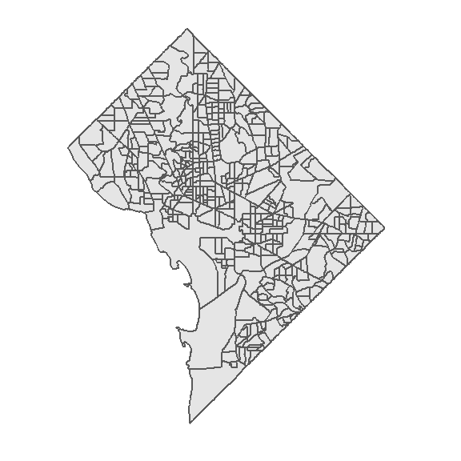

```r
dc <- tigris::block_groups(
  state = "DC",
  year = 2017,
  class = "sf",
  progress_bar = FALSE
)

ggplot(dc) +
  geom_sf()
```

What about Census tracts in Montgomery County?

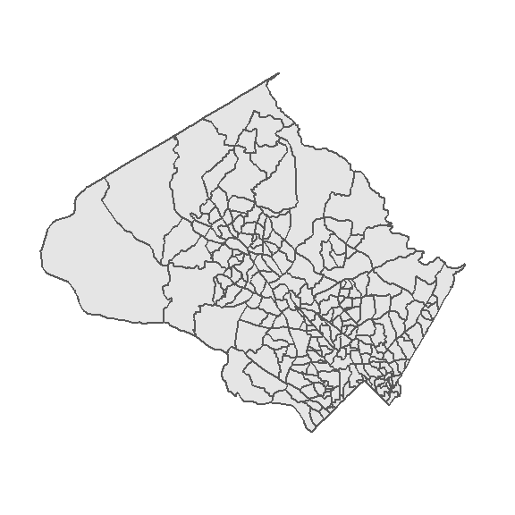

```r
montco_tracts <- tracts(
  state = "MD",
  county = "Montgomery",
  class = "sf",
  cb = T,
  progress_bar = FALSE
)

ggplot() +
  geom_sf(data = montco_tracts, mapping = aes())
```

Below are some other common places to find spatial data

- [Open Data Portals](https://opendata.dc.gov/)
- [IPUMS NHGIS](https://www.nhgis.org/documentation/gis-data)

## 4.1 Exercise 5: Using tigris

**Step 1:** Use the `school_districts()` function in tigris to download all the school districts in Oregon from the year 2015. Call the variable `or_school_districts.` Make sure to set `class = "sf"`!

**Step 2:** Use `ggplot()` and `geom_sf()` to make a plot of all the school districts in Oregon

## 4.2 Exercise 6: What are projections?

**Step 3:** Find the filepath to the `zoning_districts.shp` file in the `data` folder and read in the shapefile into R. Name the object `tor_zones`.